# Growth curves

```r
library(here)
library(tidyverse)
library(lubridate)
library(broom)
library(cowplot)
```

## Read data from plate reade file

```r
# read this file
xpt.file <- here("data", "growth-curve", "OD600_96well_16hr_37dC_shake_20200305.txt")

# number of times plate was read
xpt.reads = grep("Reads", readLines(xpt.file), value = T)%>%
  str_remove(pattern = ".*,") %>% parse_number()

# start line of OD table
start.line = grep("^Time.*A1", readLines(xpt.file))

# end line of OD table
aprox.end.line.n= floor(start.line+xpt.reads)-start.line

# read data and organize it
input <-
  read_tsv(xpt.file,
       skip = start.line-1,
       n_max = aprox.end.line.n-1,
       col_types = cols(Time = "c"))%>%
  # rename temp column
    rename("temp"=2)%>%
  # Convert time to hms
    mutate(Time=lubridate::hms(Time))%>%
    mutate(Time=as.duration(Time))%>%
  # remove empty lines
    filter(Time != 0)
```

In these files there are reads evry 2 min. I will avearge on window of 8 reads.

```r
# window size
win <- 8

#number of points after averaging
n.group <-floor( nrow(input)/win)

# remove last rows so it divides by win
input <- input[1:(win*n.group),]

input.avg <-
  input%>%
  #add grouping variable
    mutate(g=ntile(1:(win*n.group),n.group))%>%
    group_by(g)%>%
    summarise(across(where(is.numeric), ~ mean(.x, na.rm = TRUE)))%>%
  #remove grouping var
    select(-g) %>%
  # convert time to hours
    mutate(Time = Time/3600)

#trnaform to long format
d <- gather(input.avg, key="well", value = "OD600", colnames(input)[-c(1:2)])

#add metadata
meta <- read_csv(here("data", "growth-curve","20200305_spoIIE_d6_layout.csv"))
d <-merge(d, meta)
```

### plotting the data

Plot by well

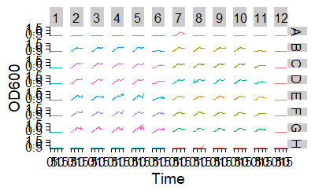

```r
d%>%
  ggplot(aes(x=Time, y=OD600))+
  geom_line(aes(color=interaction(strain,colony, media)))+
  theme_cowplot()+
  facet_grid(row~col)+
  theme(legend.position = "none")
```

```r
NA
NA
```

A few wells were ouliers and need to be filtered out:  
* coloumn 6 and 11 well got lower volume of input due to protocol error. * Wells B2 and D8 probably had some particulate matter  
* blanks of A7 and H8, seem contaminated

```r
outlier.wells <-
  meta%>%
  filter(col==6|col==11|well=="D8"|well=="A7"|well=="H8"|well=="B2")%>%
  select(well)%>%
  deframe()

d <- d%>%
  filter(!(well%in%outlier.wells))
```

Verify that initial OD was simmmilar across strains and replicates

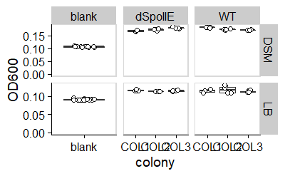

```r
d%>%
  filter(Time==min(d$Time))%>%
  ggplot(aes(x=colony, y=OD600))+
  geom_boxplot()+
  geom_jitter(width = .2, shape=21, size=2, fill= "white")+
  theme_cowplot()+
    panel_border()+
    facet_grid(media ~ strain, scales = "free")+
  ylim(0,NA)
```

### Plot by strain and media

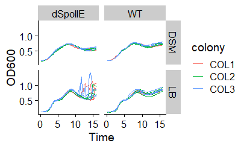

```r
d%>%
  filter(strain!="blank")%>%
  ggplot(aes(x=Time, y=OD600))+
      geom_line(aes(group=well,color=colony))+
      theme_cowplot()+
      facet_grid(media~strain)
```

```r
NA
NA
```

The replicate colonies are on top of each other.How about the different strains?

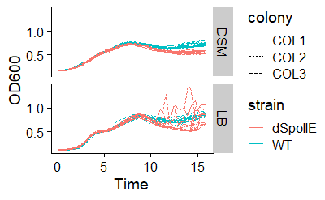

```r
d%>%
  filter(strain!="blank")%>%
  ggplot(aes(x=Time, y=OD600))+
      geom_line(aes(group=well,color=strain, linetype=colony))+
      theme_cowplot()+
      facet_grid(media~.)
```

For the growth phase they look exactly the same.

## Focus on time of growth

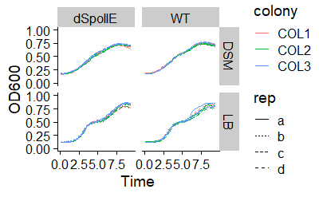

```r
d%>%
  filter(strain!="blank")%>%
  filter(Time<9.5)%>%
  group_by(well)%>%
    ggplot(aes(x=Time, y=OD600))+
      geom_line(aes(color=colony, linetype=rep))+
      theme_cowplot()+
      facet_grid(media~strain)+
  coord_cartesian(ylim=c(0,1))
```

## Growth Rates

I am using a seperate program to estimate growth rate. The program “GrowthRates” is described in Hall et al. (2013). *Growth rates made easy*. Molecular biology and evolution, 31(1), 232-238. I downloaded the executables from https://sourceforge.net/projects/growthrates/ .  
I will export the averaged data in a format suitable for GrowthRates: First column in minutes, and then the data, including a single blank well. I will also seperate LB from DSM, each with its own blank.

I have run GrowthRates externally and will now import the results into R. (GrowthRates commands: GrowthRates -i LB.txt -w 1; GrowthRates -i DSM.txt -w 1)

[output not shown]

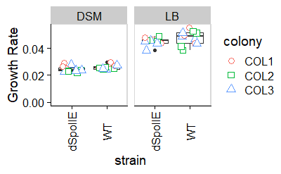

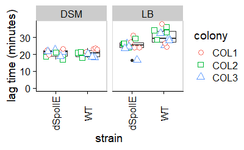

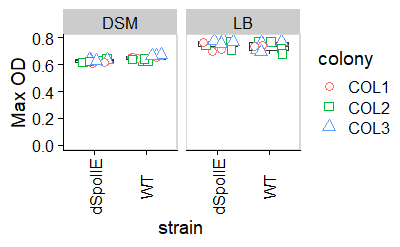

### ANOVA for LB

```r
print("== Growth Rate ==")
```

```
[1] "== Growth Rate =="
```

```r
gr%>%
  filter(strain!="blank")%>%
    filter(media=="LB")%>%
    filter(!(well%in%outlier.wells))%>%
  aov(Rate~strain+colony+rep, data=.)%>%
  summary()
```

```
            Df    Sum Sq   Mean Sq F value Pr(>F)
strain       1 3.413e-05 3.413e-05   2.838 0.1114
colony       2 1.930e-05 9.650e-06   0.803 0.4654
rep          3 1.342e-04 4.474e-05   3.721 0.0333 *
Residuals   16 1.924e-04 1.202e-05
---
Signif. codes:  0 ‘***’ 0.001 ‘**’ 0.01 ‘*’ 0.05 ‘.’ 0.1 ‘ ’ 1
```

```r
print("== lag time (minutes) ==")
```

```
[1] "== lag time (minutes) =="
```

```r
gr%>%
  filter(strain!="blank")%>%
    filter(media=="LB")%>%
  aov(`lag time (minutes)`~strain+colony+rep, data=.)%>%
  summary()
```

```
            Df Sum Sq Mean Sq F value  Pr(>F)
strain       1 157.32  157.32  14.510 0.00154 **
colony       2  64.65   32.32   2.981 0.07934 .
rep          3 109.39   36.46   3.363 0.04495 *
Residuals   16 173.47   10.84
---
Signif. codes:  0 ‘***’ 0.001 ‘**’ 0.01 ‘*’ 0.05 ‘.’ 0.1 ‘ ’ 1
7 observations deleted due to missingness
```

```r
print("== Max OD ==")
```

```
[1] "== Max OD =="
```

```r
gr%>%
  filter(strain!="blank")%>%
    filter(media=="LB")%>%
  mutate(`Max OD`=as.numeric(`Max OD`))%>%
  aov(`Max OD`~strain+colony+rep, data=.)%>%
  summary()
```

```
            Df   Sum Sq   Mean Sq F value Pr(>F)
strain       1 0.001906 0.0019062   2.304  0.149
colony       2 0.002261 0.0011305   1.366  0.283
rep          3 0.005084 0.0016946   2.048  0.148
Residuals   16 0.013238 0.0008274
7 observations deleted due to missingness
```

lag time (minutes) by strain post hoc

```r
gr%>%
  filter(strain!="blank")%>%
    filter(media=="LB")-> tmp
t.test(tmp$`lag time (minutes)`~ tmp$strain)
```

```
    Welch Two Sample t-test

data:  tmp$`lag time (minutes)` by tmp$strain
t = -3.053, df = 19.207, p-value = 0.006487
alternative hypothesis: true difference in means is not equal to 0
95 percent confidence interval:
 -8.822289 -1.648923
sample estimates:
mean in group dSpoIIE      mean in group WT
             25.29167              30.52727
```

### ANOVA for DSM

```r
print("== Growth Rate ==")
```

```
[1] "== Growth Rate =="
```

```r
gr%>%
  filter(strain!="blank")%>%
    filter(media=="DSM")%>%
    filter(!(well%in%outlier.wells))%>%
  aov(Rate~strain+colony+rep, data=.)%>%
  summary()
```

```
            Df    Sum Sq   Mean Sq F value Pr(>F)
strain       1 8.550e-06 8.547e-06   3.032 0.1009
colony       2 2.370e-05 1.185e-05   4.203 0.0341 *
rep          3 6.930e-06 2.309e-06   0.819 0.5022
Residuals   16 4.511e-05 2.820e-06
---
Signif. codes:  0 ‘***’ 0.001 ‘**’ 0.01 ‘*’ 0.05 ‘.’ 0.1 ‘ ’ 1
```

```r
print("== lag time (minutes) ==")
```

```
[1] "== lag time (minutes) =="
```

```r
gr%>%
  filter(strain!="blank")%>%
    filter(media=="DSM")%>%
  aov(`lag time (minutes)`~strain+colony+rep, data=.)%>%
  summary()
```

```
            Df Sum Sq Mean Sq F value  Pr(>F)
strain       1   0.01   0.009   0.003 0.95361
colony       2  39.07  19.537   7.660 0.00464 **
rep          3   9.65   3.216   1.261 0.32116
Residuals   16  40.81   2.550
---
Signif. codes:  0 ‘***’ 0.001 ‘**’ 0.01 ‘*’ 0.05 ‘.’ 0.1 ‘ ’ 1
7 observations deleted due to missingness
```

```r
print("== Max OD ==")
```

```
[1] "== Max OD =="
```

```r
gr%>%
  filter(strain!="blank")%>%
    filter(media=="DSM")%>%
  mutate(`Max OD`=as.numeric(`Max OD`))%>%
  aov(`Max OD`~strain+colony+rep, data=.)%>%
  summary()
```

```
            Df    Sum Sq   Mean Sq F value   Pr(>F)
strain       1 0.0030266 0.0030266  21.906 0.000251 ***
colony       2 0.0018415 0.0009207   6.664 0.007847 **
rep          3 0.0000277 0.0000092   0.067 0.976731
Residuals   16 0.0022106 0.0001382
---
Signif. codes:  0 ‘***’ 0.001 ‘**’ 0.01 ‘*’ 0.05 ‘.’ 0.1 ‘ ’ 1
7 observations deleted due to missingness
```

Max OD by strain post hoc

```r
gr%>%
  filter(strain!="blank")%>%
    filter(media=="DSM")-> tmp
t.test(as.numeric(tmp$`Max OD`)~ tmp$strain)
```

```
    Welch Two Sample t-test

data:  as.numeric(tmp$`Max OD`) by tmp$strain
t = -3.8954, df = 18.396, p-value = 0.001024
alternative hypothesis: true difference in means is not equal to 0
95 percent confidence interval:
 -0.03533099 -0.01059795
sample estimates:
mean in group dSpoIIE      mean in group WT
            0.6272292             0.6501936
```

```r
t.test(as.numeric(tmp$Rate)~ tmp$strain)
```

```
    Welch Two Sample t-test

data:  as.numeric(tmp$Rate) by tmp$strain
t = -1.5547, df = 20.664, p-value = 0.1352
alternative hypothesis: true difference in means is not equal to 0
95 percent confidence interval:
 -0.0028544080  0.0004136505
sample estimates:
mean in group dSpoIIE      mean in group WT
           0.02457417            0.02579455
```

```r
t.test(as.numeric(tmp$`lag time (minutes)`)~ tmp$strain)
```

```
    Welch Two Sample t-test

data:  as.numeric(tmp$`lag time (minutes)`) by tmp$strain
t = 0.045624, df = 20.645, p-value = 0.964
alternative hypothesis: true difference in means is not equal to 0
95 percent confidence interval:
 -1.758136  1.836924
sample estimates:
mean in group dSpoIIE      mean in group WT
             20.66667              20.62727
```

# **Take aways**

## DSM

The plan for the co-evolution experiment is to use DSM. Significant strain dependent differences are seen for the **Max OD**. WT has a higher average Max OD, but the difference seems quite small. I should say that seeing a difference in this parameter is not surprising, as that is the point where the two strains are expected to behave differently: WT sporulates, while $\Delta$spoIIE cannot.

## LB

# presentable plot

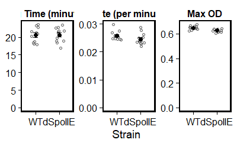

```r
d.plot <- gr%>%
  filter(strain != "blank") %>%
  filter(media == "DSM") %>%
# long format for panels
  mutate('Max OD' =as.numeric(`Max OD`))%>%
  select(-R, `Rate (per minute)` = Rate,
         `Lag Time (minutes)` = `lag time (minutes)`)%>%
  pivot_longer(cols = 8:10,
               values_to = "val", names_to = "param")%>%
  filter(!is.na(val))%>%
  mutate(param = fct_relevel(param,  c("Lag Time (minutes)","Rate (per minute)","Max OD")))

#summary stats
d.plot.sum <-
  d.plot%>%
  group_by(strain, param) %>%
  summarise(n = n(),
            m = mean(val),
            sem = sd(val)/sqrt(n))
#plot
d.plot%>%
  ggplot(aes(x = fct_rev(strain), y = val))+
  geom_jitter(shape = 21, size = 1.5, fill = "grey",
              alpha = 0.5, height = 0, width = 0.2)+
  geom_errorbar(data = d.plot.sum,
                aes(y = m, ymin = m-sem, ymax = m+sem),
                size = .5, width = 0.2)+
  geom_point(data = d.plot.sum, aes(y=m),
                size = 2, shape = 21, fill = "black")+
  theme_cowplot()+
  panel_border(color = "black", size = 1.5)+
  scale_shape_manual(values = c(21,22,24))+
  facet_wrap(~param, scales = "free" )+
    theme(strip.background = element_blank(),
          strip.text = element_text(face = "bold"),
          axis.title.y = element_blank())+
  ylim(0,NA)+
  xlab("Strain")+
  ggsave(here("plots","DSM_growth-params.png"), width = 7, height = 3)
```